# London Fire Brigade Incident Response Times

[figure not shown]

### Investigating the London Fire Brigades's incident response times across the 32 London boroughs from 2010 to 2021

# Our Data

### We have the the average time taken to respond to an emergency incident from the time the 999 call was answered, until the time the first fire engine arrived on scene, for each London borough from 2010 to 2021

| 2 area | 2010 | 2011 | 2012 | 2013 | 2014 | 2015 | 2016 | 2017 | 2018 | 2019 | 2020 | 2021 | mean |
| --- | --- | --- | --- | --- | --- | --- | --- | --- | --- | --- | --- | --- | --- |
| camden | 387 | 381 | 377 | 367 | 392 | 406 | 401 | 392 | 391 | 392 | 382 | 392 | 388.33 |
| city of london | 388 | 392 | 390 | 378 | 399 | 411 | 400 | 387 | 392 | 389 | 377 | 364 | 388.92 |
| hackney | 406 | 390 | 391 | 384 | 406 | 411 | 399 | 394 | 391 | 394 | 388 | 396 | 395.83 |
| hammersmith and fulham | 420 | 413 | 403 | 386 | 398 | 400 | 403 | 386 | 386 | 390 | 380 | 383 | 395.67 |
| haringey | 453 | 447 | 437 | 434 | 436 | 438 | 398 | 425 | 416 | 428 | 410 | 418 | 428.33 |
| islington | 390 | 385 | 382 | 377 | 398 | 404 | 394 | 383 | 373 | 372 | 369 | 389 | 384.67 |
| kensington and chelsea | 373 | 368 | 367 | 365 | 377 | 379 | 371 | 361 | 364 | 365 | 352 | 355 | 366.42 |

There are 32 London Boroughs. As we'll see, it makes sense to separate Inner London and Outer London

Colours

## Has the response time improved over 10 years?

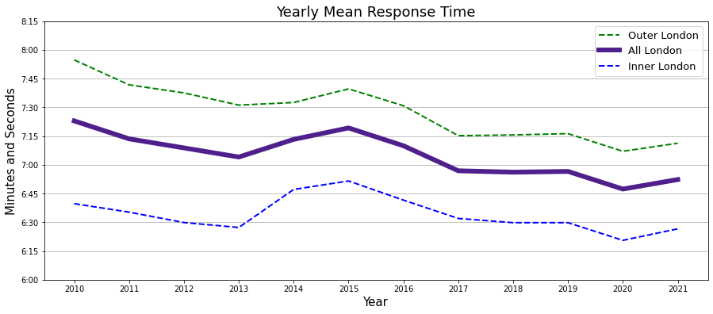

It seems to have generally improved over 10 years. Inner London has consistently shorter response times than Outer London. For the rest of the report we will analyse Outer and Inner London separately.

## How has it improved over 10 years by borough?

We saw that overall average response time is lower now than 10 years ago. But is this true for each individual borough?

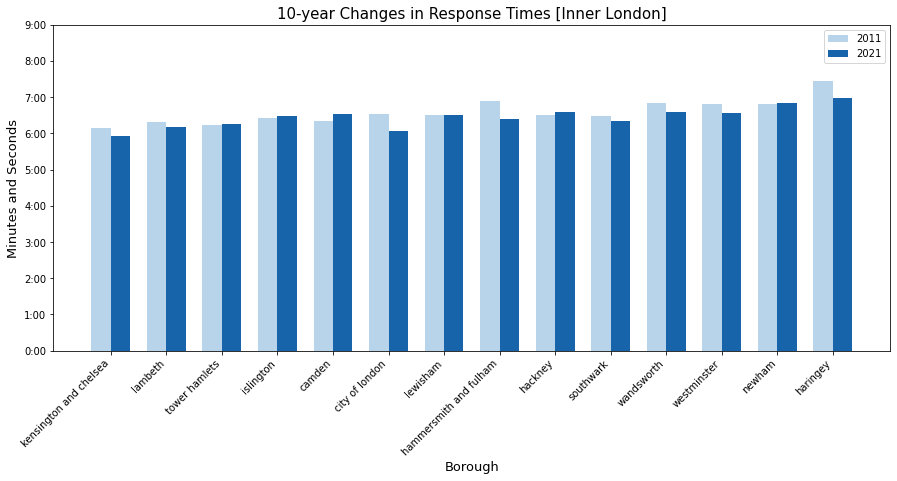

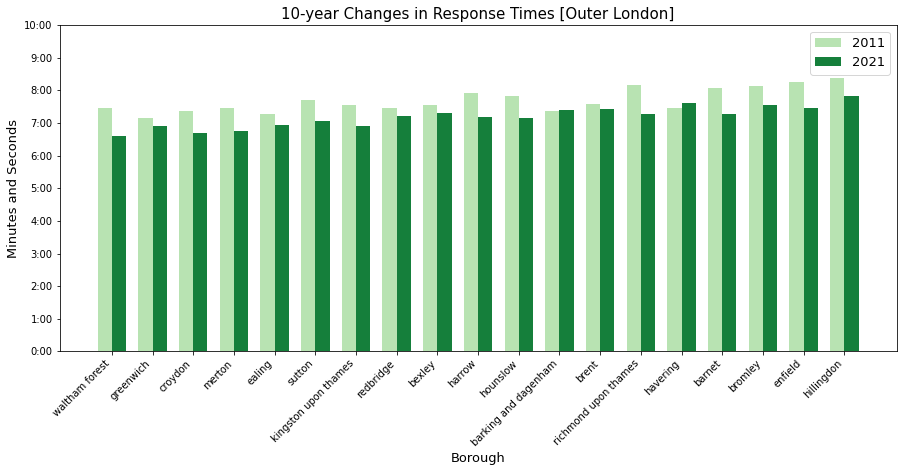

The large majority of boroughs in Outer London have lower average response times compared to 10 years ago

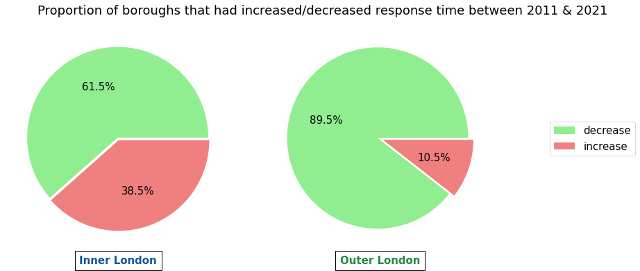

From 2011 to 2021, the majority of boroughs in Outer and Inner London experienced an decrease in response times. The proportion is larger in Outer London than Inner London however.

## How has it improved over 1 year by borough?

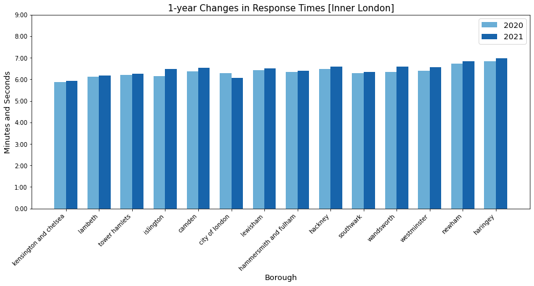

The large majority of boroughs in Inner London have slightly higher response times compared to last year

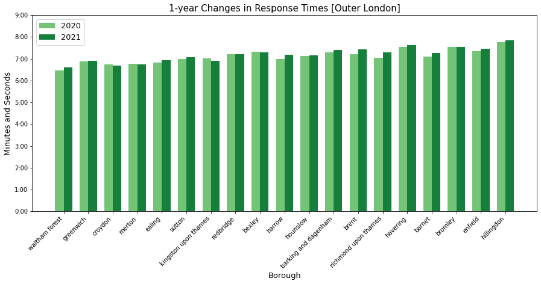

The majority of boroughs in Outer London have slightly higher response times compared to last year

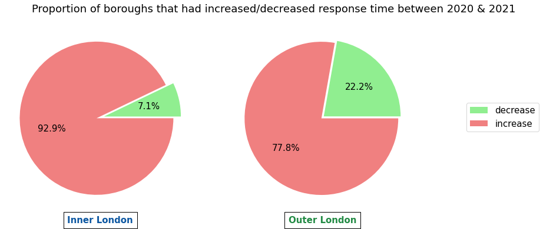

From 2020 to 2021, the majority of boroughs in Outer and Inner London experienced an increase in response times.

# Looking at our data geograpically

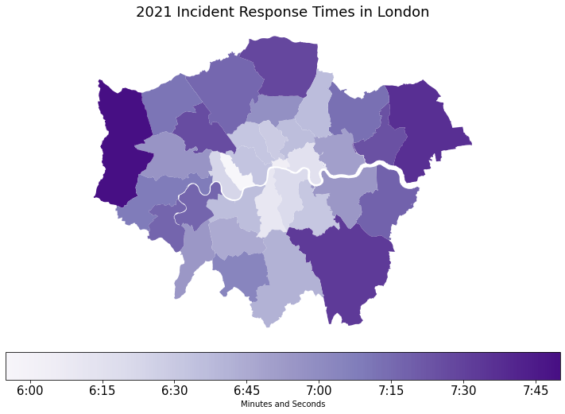

We can see a clear colour difference between Inner and Outer London, so lets look at each separately.

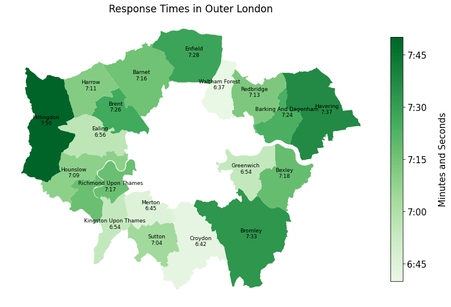

Hillingdon in the west and Havering in the east have the longest times. Roughly 1 minute longer than Croydon and Merton in the south.

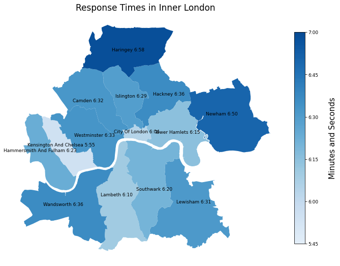

Haringay and Newham have the longest response times. City of London is the smallest area but has the second shortest response time.

## Average Response Time vs Area Size

We've seen the response varies between Inner and Outer London. But is there anything else that influences response time? We have the area size of each borough, so let's explore how it affects response time.

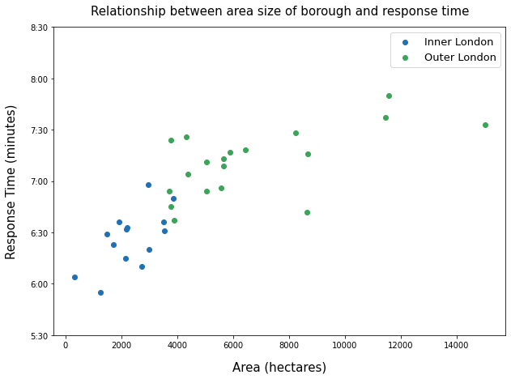

On inspection, it looks like there is a linear relationship between a borough's Area and Response Time

### Inner London Linear Regression

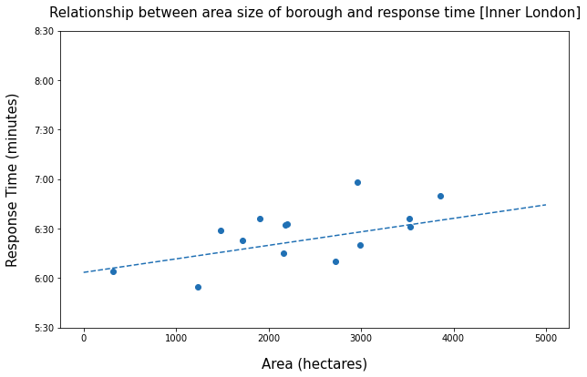

### Outer London Linear Regression

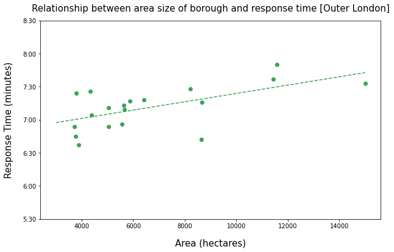